# Linear Regression Analysis Report

Grace Hardy

2026-02-01

# 1. Exploratory Analysis

Print the first few rows of the insurance data:

```
##   age    sex    bmi children smoker    region   charges
## 1  19 female 27.900        0    yes southwest 16884.924
## 2  18   male 33.770        1     no southeast  1725.552
## 3  28   male 33.000        3     no southeast  4449.462
## 4  33   male 22.705        0     no northwest 21984.471
## 5  32   male 28.880        0     no northwest  3866.855
## 6  31 female 25.740        0     no southeast  3756.622
```

Print the last few rows of the insurance data:

```
##      age    sex   bmi children smoker    region   charges
## 1333  52 female 44.70        3     no southwest 11411.685
## 1334  50   male 30.97        3     no northwest 10600.548
## 1335  18 female 31.92        0     no northeast  2205.981
## 1336  18 female 36.85        0     no southeast  1629.833
## 1337  21 female 25.80        0     no southwest  2007.945
## 1338  61 female 29.07        0    yes northwest 29141.360
```

Column headings look as if they have accurate meaning, no obvious data errors or formatting issues.

Summary statistics of the insurance data:

```
##       age            sex                 bmi           children
##  Min.   :18.00   Length:1338        Min.   :15.96   Min.   :0.000
##  1st Qu.:27.00   Class :character   1st Qu.:26.30   1st Qu.:0.000
##  Median :39.00   Mode  :character   Median :30.40   Median :1.000
##  Mean   :39.21                      Mean   :30.66   Mean   :1.095
##  3rd Qu.:51.00                      3rd Qu.:34.69   3rd Qu.:2.000
##  Max.   :64.00                      Max.   :53.13   Max.   :5.000
##     smoker             region             charges
##  Length:1338        Length:1338        Min.   : 1122
##  Class :character   Class :character   1st Qu.: 4740
##  Mode  :character   Mode  :character   Median : 9382
##                                        Mean   :13270
##                                        3rd Qu.:16640
##                                        Max.   :63770
```

Display the type of each variable:

```
## 'data.frame':    1338 obs. of  7 variables:
##  $ age     : int  19 18 28 33 32 31 46 37 37 60 ...
##  $ sex     : chr  "female" "male" "male" "male" ...
##  $ bmi     : num  27.9 33.8 33 22.7 28.9 ...
##  $ children: int  0 1 3 0 0 0 1 3 2 0 ...
##  $ smoker  : chr  "yes" "no" "no" "no" ...
##  $ region  : chr  "southwest" "southeast" "southeast" "northwest" ...
##  $ charges : num  16885 1726 4449 21984 3867 ...
```

Minimum and Maximum seem reasonable values. For charges, the mean is significantly larger than the median which could indicate right skewness or presence of outlier values, this is further indicated by the large max value in comparison to the 3rd quartile value. No indication of any missing values.

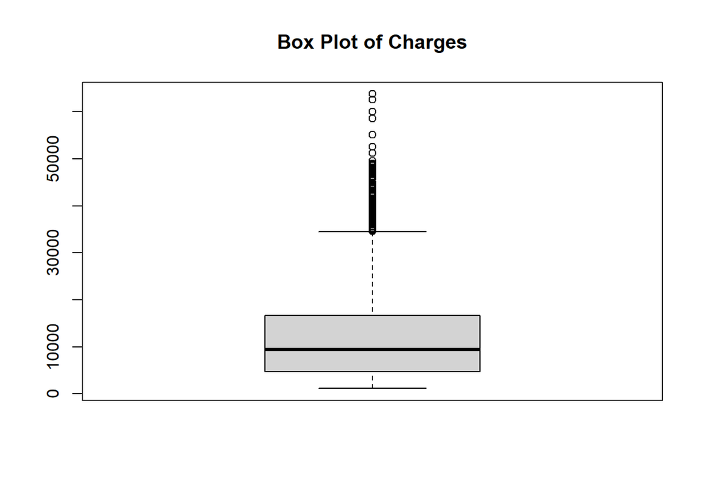

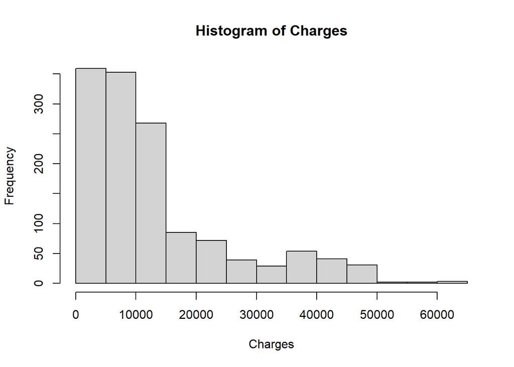

Extreme values indicated by box and histogram plots are to be kept as they are plausible real-world values.

Check before fitting the model, conceptually linear regression is a good fit against numeric variables:

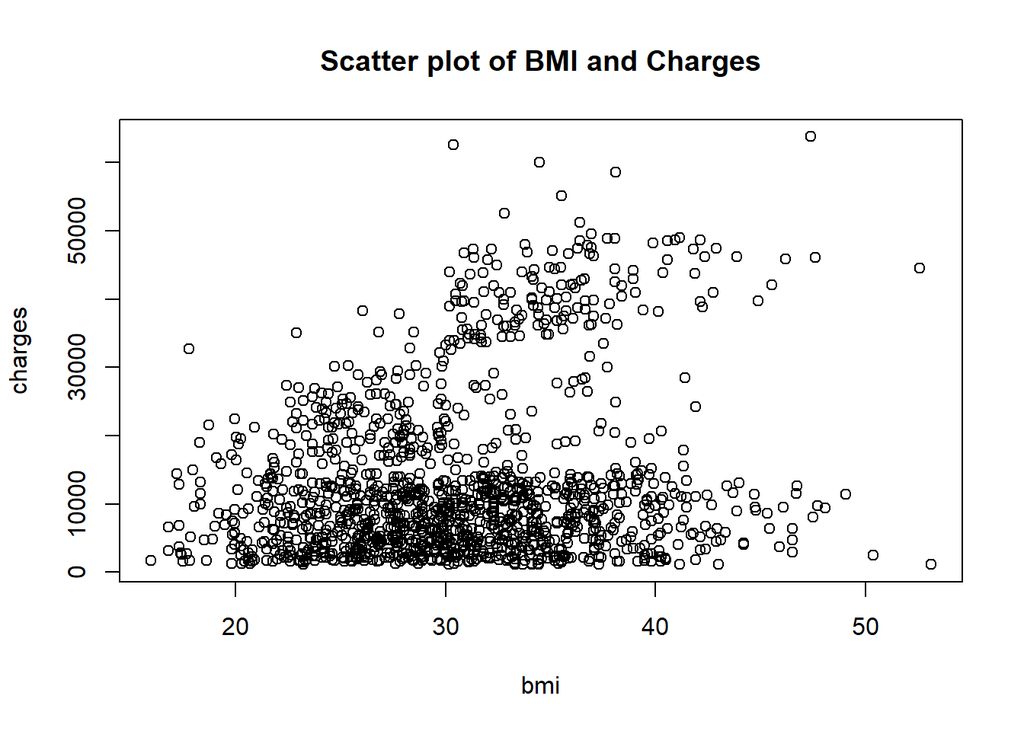

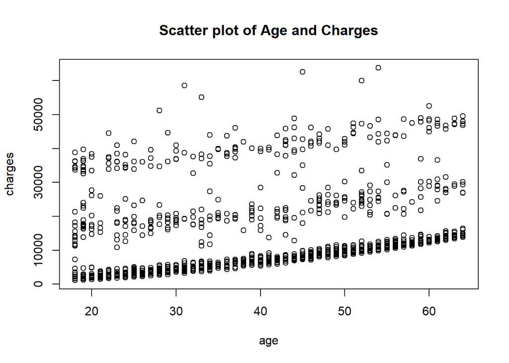

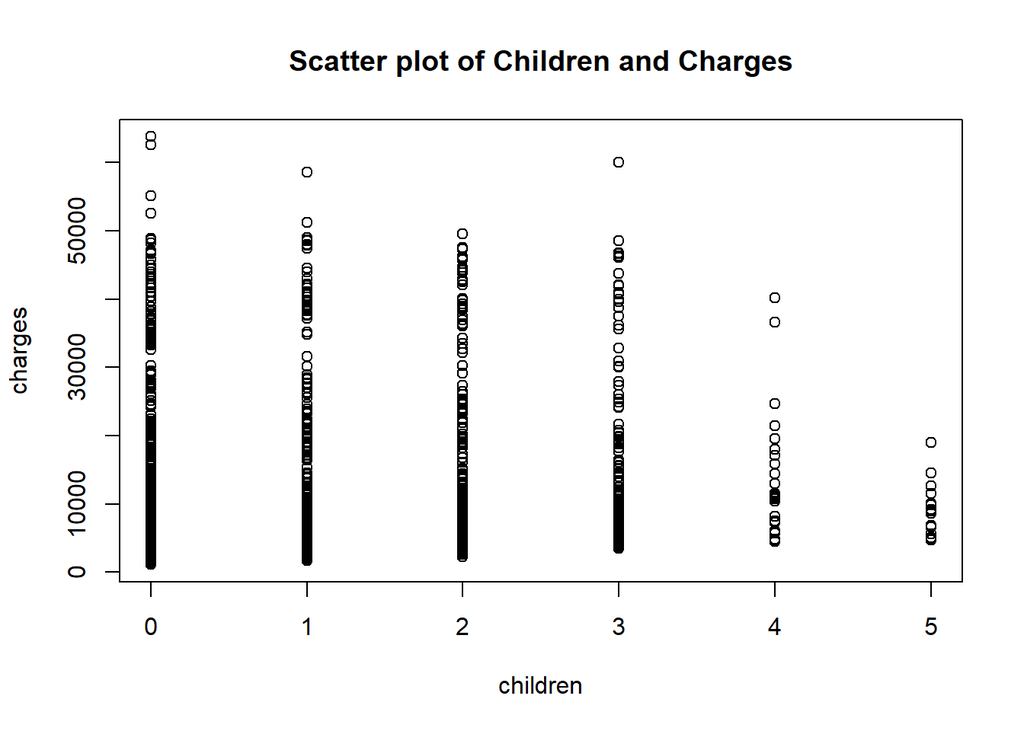

Scatter plot indicates some correlation between BMI and charges, indicating potential suitability for a linear regression model. Same can be said between age and charges. In both cases, there are other clusters that may imply that another variable should be included in the model.

# 2. Fit Linear Regression model

```r
model <- lm(charges ~ bmi + sex + age + region + children + smoker)
```

# 3. Model Summary

```
##
## Call:
## lm(formula = charges ~ bmi + sex + age + region + children +
##     smoker)
##
## Residuals:
##      Min       1Q   Median       3Q      Max
## -11304.9  -2848.1   -982.1   1393.9  29992.8
##
## Coefficients:
##                 Estimate Std. Error t value Pr(>|t|)
## (Intercept)     -11938.5      987.8 -12.086  < 2e-16 ***
## bmi                339.2       28.6  11.860  < 2e-16 ***
## sexmale           -131.3      332.9  -0.394 0.693348
## age                256.9       11.9  21.587  < 2e-16 ***
## regionnorthwest   -353.0      476.3  -0.741 0.458769
## regionsoutheast  -1035.0      478.7  -2.162 0.030782 *
## regionsouthwest   -960.0      477.9  -2.009 0.044765 *
## children           475.5      137.8   3.451 0.000577 ***
## smokeryes        23848.5      413.1  57.723  < 2e-16 ***
## ---
## Signif. codes:  0 '***' 0.001 '**' 0.01 '*' 0.05 '.' 0.1 ' ' 1
##
## Residual standard error: 6062 on 1329 degrees of freedom
## Multiple R-squared:  0.7509, Adjusted R-squared:  0.7494
## F-statistic: 500.8 on 8 and 1329 DF,  p-value: < 2.2e-16
```

P-value’s for bmi, age, children and smoker are all less than 0.05 which indicates they are statistically significant in predicting charges.

```
##
## Call:
## lm(formula = charges ~ bmi + age + children + smoker)
##
## Residuals:
##      Min       1Q   Median       3Q      Max
## -11897.9  -2920.8   -986.6   1392.2  29509.6
##
## Coefficients:
##              Estimate Std. Error t value Pr(>|t|)
## (Intercept) -12102.77     941.98 -12.848  < 2e-16 ***
## bmi            321.85      27.38  11.756  < 2e-16 ***
## age            257.85      11.90  21.675  < 2e-16 ***
## children       473.50     137.79   3.436 0.000608 ***
## smokeryes    23811.40     411.22  57.904  < 2e-16 ***
## ---
## Signif. codes:  0 '***' 0.001 '**' 0.01 '*' 0.05 '.' 0.1 ' ' 1
##
## Residual standard error: 6068 on 1333 degrees of freedom
## Multiple R-squared:  0.7497, Adjusted R-squared:  0.7489
## F-statistic: 998.1 on 4 and 1333 DF,  p-value: < 2.2e-16
```

The R-Square value of 0.7497 indicate that this model has fairly good predictive power as closer to one than zero.

However, residual standard error of 6068 on 1333 degrees of freedom indicates that the average amount that the data points deviate from the regression line is quite high, suggesting that the model is weaker at matching the data.

When comparing 2 people with all other variables the same, the average predicted charges grow by 23811.40 if the person is a smoker.

# 4. Check Assumptions

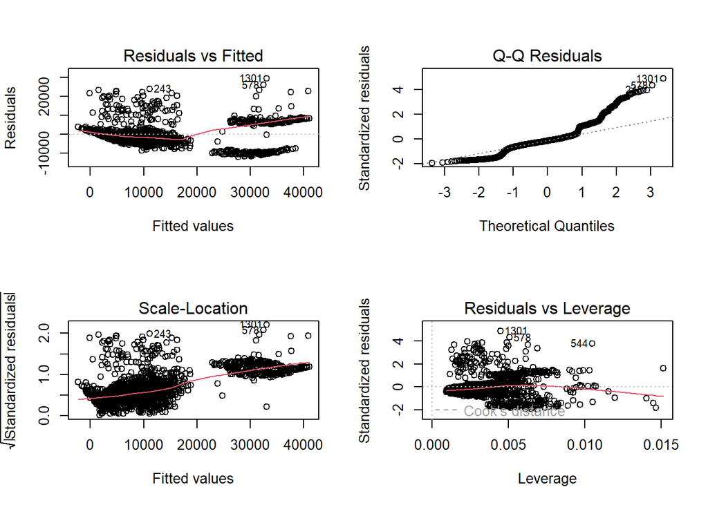

# 5. Predicting Values

```
##       1
## 34761.3
```

# 6 . Visualise

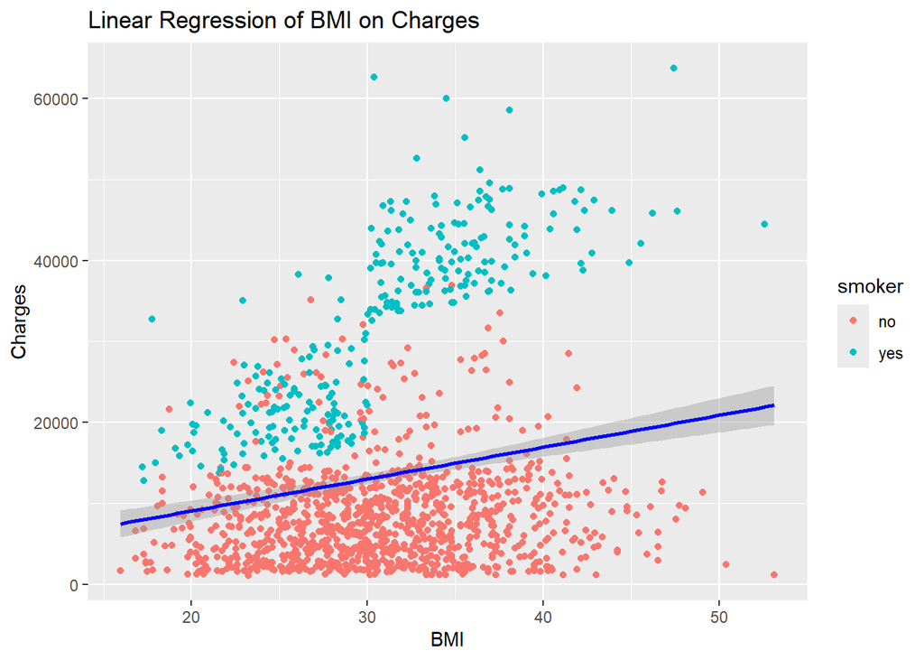

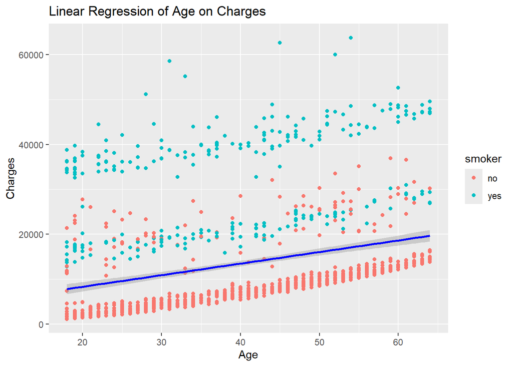

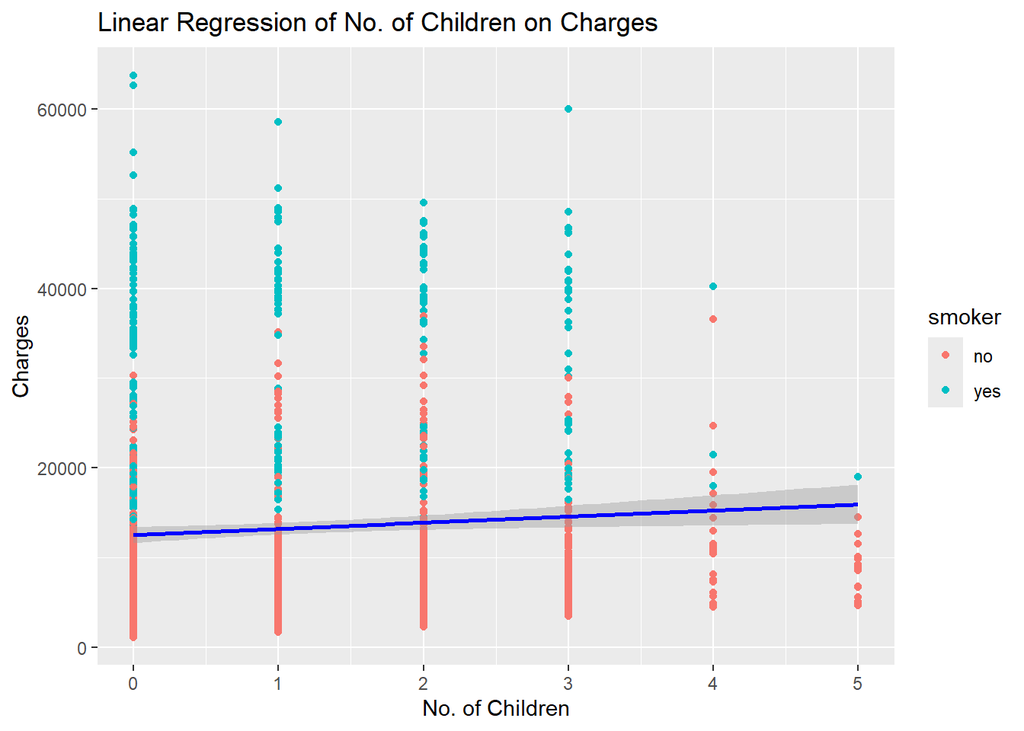

# 7. Conclusion

Age, BMI, and smoking status show strong statistical significance in predicting healthcare charges due to their small p-values.The linear regression is limited as Homoscedasticity and Normality assumptions were not met.